# Machine Learning Algorithms Documentation

Geiser, Gruen, Hefti, Kuster

08/01/2021

**Data preparation**

**Dataset - German Housing Data**

Origin data set cleaned:

Variable rooms, bathrooms, bedrooms, floors, garages, Year_built, Year_renovated changed from decimal to integer Subset with buildings up to 20 rooms for our analysis created Rooms with .5 rounded up Levels of the variable Energy_source and Garagetype transformed.

**Load of the cleaned dataset**

```r
data <- read.csv('german_housing_cleaned.csv',header =T, encoding='UTF-8')
head(data)
```

```
##     Price              Type Living_space Lot Rooms Bedrooms Bathrooms Floors
## 1  498000 Multiple dwelling       106.00 229     5        3         1      2
## 2  495000 Mid-terrace house       140.93 517     6        3         2     NA
## 3  749000         Farmhouse       162.89  82     5        3         2      4
## 4  259000         Farmhouse       140.00 814     4       NA         2      2
## 5  469000 Multiple dwelling       115.00 244     4        2         1     NA
## 6 1400000 Mid-terrace house       310.00 860     8       NA        NA      3
##   Year_built Furnishing_quality Year_renovated   Condition         Heating
## 1       2005             normal             NA refurbished central heating
## 2       1994              basic             NA refurbished   stove heating
## 3       2013                                NA dilapidated   stove heating
## 4       1900              basic           2000 fixer-upper central heating
## 5       1968            refined           2019 refurbished central heating
## 6       1969              basic             NA  maintained
##      Energy_source Energy_efficiency_class             State              City
## 1      natural gas                       D Baden-Württemberg     Bodenseekreis
## 2                                          Baden-Württemberg  Konstanz (Kreis)
## 3 district heating                       B Baden-Württemberg Esslingen (Kreis)
## 4      electricity                       G Baden-Württemberg  Waldshut (Kreis)
## 5              oil                       F Baden-Württemberg Esslingen (Kreis)
## 6              oil                         Baden-Württemberg         Stuttgart
##                     Place Garages  Garagetype
## 1             Bermatingen       2 Parking lot
## 2                   Engen       7 Parking lot
## 3              Ostfildern       1      Garage
## 4 Bonndorf im Schwarzwald       1      Garage
## 5 Leinfelden-Echterdingen       1      Garage
## 6                     Süd       2      Garage
```

**Inspection of all variables**

```r
str(data)
summary(data)
colnames(data)
```

**Analysis of the distribution of the variables: ‘Price’, ‘Living_space’, ‘Rooms’ and ‘Lot’**

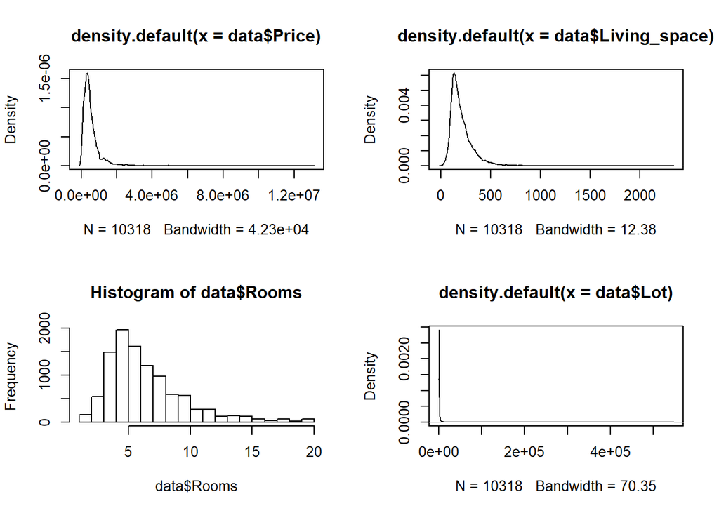

```r
par(mfrow = c(2,2))

#Price
plot(density(data$Price))

#Living_space
plot(density(data$Living_space))

#Rooms
hist(data$Rooms)

#Lot
plot(density(data$Lot))
```

Result: The variables are right skewed

**Log Transformation of variables**

Therefore we will use the Log Transformation of the variables ‘Price’, ‘Living_space’, ‘Rooms’, ‘Lot’ to get a nearly normal distribution

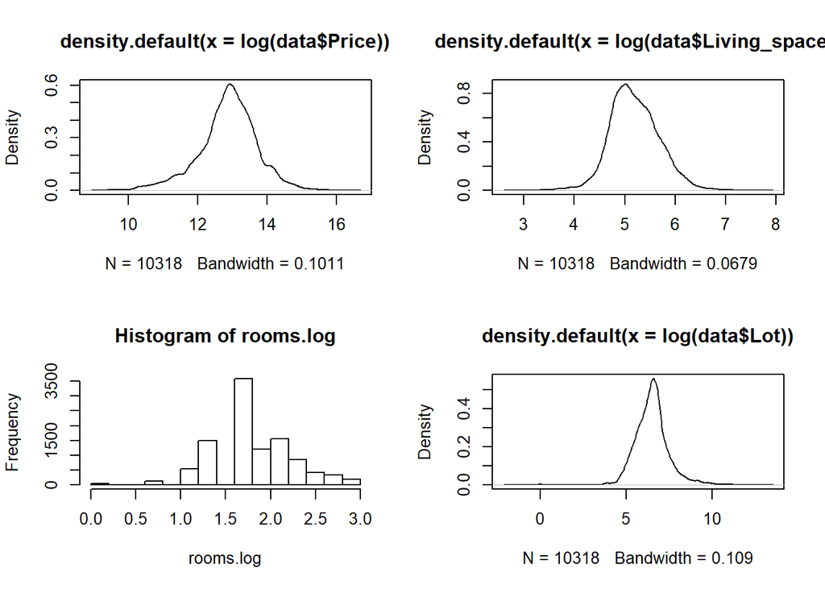

```r
par(mfrow = c(2,2))

#Price
price.log <- density(log(data$Price))
plot(price.log)

#Living_space
living.log <- density(log(data$Living_space))
plot(living.log)

#Rooms
rooms.log <- log(data$Rooms)
hist(rooms.log)

#Lot
lot.log <- density(log(data$Lot))
plot(lot.log)
```

**Add new columns with log transformed variables price, living space and rooms**

```r
data1 <- data
data1$log.price <- log(data1$Price)
data1$log.living <- log(data1$Living_space)
data1$log.rooms <- log(data1$Rooms)
```

# 1 Week 1 - Linear Models

## 1.1 Data Visualisation and Linear regressions

The variables Price, Living_space and Rooms are checked for na values

```r
options(scipen=999) #block scientific notation
library(ggplot2)
attach(data)
any(is.na(Price))
```

```
## [1] FALSE
```

```r
any(is.na(Living_space))
```

```
## [1] FALSE
```

```r
any(is.na(Rooms))
```

```
## [1] FALSE
```

## 1.2 Scatterplot with regression line for log(Price) against log(Living_space)

We plot the response variable “Price” against the predictor “Living_Space” to get a first impression and grahical analysis.

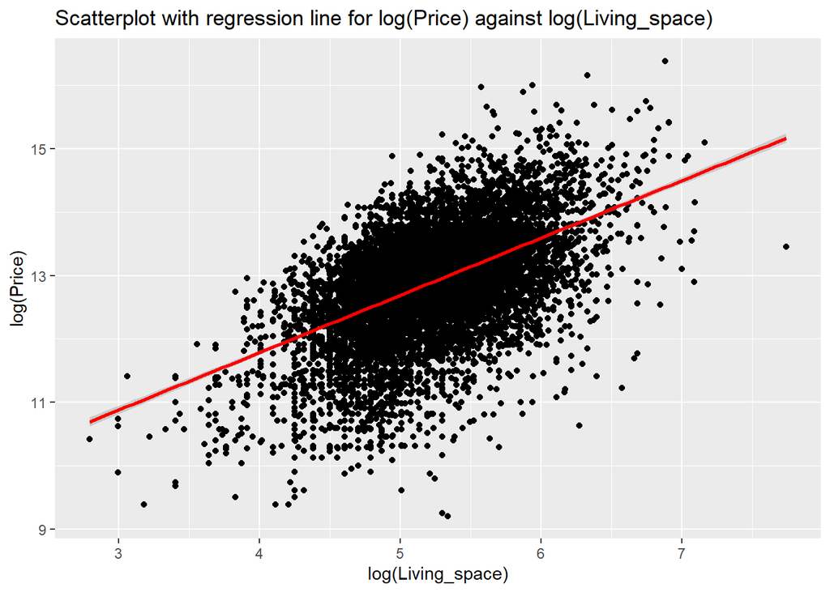

```r
#Living_space
ggplot(data, aes(log(Living_space), log(Price))) + geom_point() + geom_smooth(method = lm, se = T, color = 'red') + ggtitle('Scatterplot with regression line for log(Price) against log(Living_space)')
```

## 1.3 Fitting a Simple Linear regression of log(Price) against log(Living_space) and check the coefficients

```r
#linear model
lm.log.price_living <- lm(log(Price) ~ log(Living_space))
summary(lm.log.price_living)
```

```
##
## Call:
## lm(formula = log(Price) ~ log(Living_space))
##
## Residuals:
##     Min      1Q  Median      3Q     Max
## -3.7836 -0.4079  0.0856  0.4683  2.7581
##
## Coefficients:
##                   Estimate Std. Error t value            Pr(>|t|)
## (Intercept)        8.17522    0.07596  107.62 <0.0000000000000002 ***
## log(Living_space)  0.90280    0.01455   62.05 <0.0000000000000002 ***
## ---
## Signif. codes:  0 '***' 0.001 '**' 0.01 '*' 0.05 '.' 0.1 ' ' 1
##
## Residual standard error: 0.7145 on 10316 degrees of freedom
## Multiple R-squared:  0.2718, Adjusted R-squared:  0.2717
## F-statistic:  3850 on 1 and 10316 DF,  p-value: < 0.00000000000000022
```

```r
#estimated regression coefficients
living.coefs <- coef(lm.log.price_living)
living.coefs
```

```
##       (Intercept) log(Living_space)
##         8.1752232         0.9028032
```

```r
#p-values
summary(lm.log.price_living)$coefficients
```

```
##                    Estimate Std. Error   t value Pr(>|t|)
## (Intercept)       8.1752232 0.07596044 107.62475        0
## log(Living_space) 0.9028032 0.01455063  62.04563        0
```

Result: very significant p-values for Price ~ Living_space. We can assume that the variable Living_space has an effect on the dependent variable (Price) with a positive correlation, meaning: if the Living_space parameter increase in value also the Price of the property will increase.

We interpret the intercept and the second coefficient, the slope, we exponentiate the values. The results are: For the intercept exp(8.17522)= 3551.84 and the slope exp(0.9028)=2.47

Interpretation: It seems to be a positive relationship between these two variables. More livingspace seems to have a higher price. So we fit a simple regression model to the data. With a livingspace of 0 the price would be 3551.84 EURO and with each unit increase of the livingspace the price increase by 2.47 EURO which does not make much sense. The p-value is very small therefore we have a strong evidence that the slope for livingspace is not flat.

### 1.3.1 Measures of fit

```r
#r.squared
summary(lm.log.price_living)$r.squared
```

```
## [1] 0.27176
```

```r
#adj.r.squared
summary(lm.log.price_living)$adj.r.squared
```

```
## [1] 0.2716894
```

Note: There is no threshold to define a model fit to be good, however a model that explain all the variability of the data would have an R^2 of 1.

## 1.4 Linear regression of log(Price) against log(Living_space) including the Type and finding the intercept for the different Types.

```r
##linear model
lm.log.price_living_type <- lm(log(Price) ~ log(Living_space) + Type)
summary(lm.log.price_living_type)
```

```
##
## Call:
## lm(formula = log(Price) ~ log(Living_space) + Type)
##
## Residuals:
##     Min      1Q  Median      3Q     Max
## -3.9802 -0.3849  0.0716  0.4556  2.7356
##
## Coefficients:
##                          Estimate Std. Error t value             Pr(>|t|)
## (Intercept)               7.47225    0.09409  79.414 < 0.0000000000000002 ***
## log(Living_space)         0.99691    0.01679  59.378 < 0.0000000000000002 ***
## TypeBungalow              0.24691    0.05737   4.304    0.000016956457415 ***
## TypeCastle               -0.33356    0.31169  -1.070             0.284573
## TypeCorner house         -0.14759    0.06058  -2.436             0.014857 *
## TypeDuplex               -0.06320    0.03900  -1.620             0.105186
## TypeFarmhouse             0.26026    0.04599   5.659    0.000000015603919 ***
## TypeMid-terrace house     0.24470    0.03679   6.651    0.000000000030494 ***
## TypeMultiple dwelling     0.35983    0.05029   7.155    0.000000000000891 ***
## TypeResidential property  0.17411    0.05094   3.418             0.000634 ***
## TypeSingle dwelling       0.39721    0.04091   9.708 < 0.0000000000000002 ***
## TypeSpecial property      0.46909    0.05103   9.193 < 0.0000000000000002 ***
## TypeVilla                 0.70309    0.05077  13.847 < 0.0000000000000002 ***
## ---
## Signif. codes:  0 '***' 0.001 '**' 0.01 '*' 0.05 '.' 0.1 ' ' 1
##
## Residual standard error: 0.6912 on 10305 degrees of freedom
## Multiple R-squared:  0.3193, Adjusted R-squared:  0.3185
## F-statistic: 402.8 on 12 and 10305 DF,  p-value: < 0.00000000000000022
```

```r
#estimated regression coefficients
living_type.coefs <- coef(lm.log.price_living_type)
living_type.coefs
```

```
##              (Intercept)        log(Living_space)             TypeBungalow
##                7.4722543                0.9969080                0.2469139
##               TypeCastle         TypeCorner house               TypeDuplex
##               -0.3335592               -0.1475928               -0.0631954
##            TypeFarmhouse    TypeMid-terrace house    TypeMultiple dwelling
##                0.2602565                0.2447012                0.3598267
## TypeResidential property      TypeSingle dwelling     TypeSpecial property
##                0.1741124                0.3972086                0.4690858
##                TypeVilla
##                0.7030881
```

```r
#intercept of Type "NULL"
notype.coefs <- coef(lm.log.price_living_type)['(Intercept)']
notype.coefs
```

```
## (Intercept)
##    7.472254
```

```r
#intercept of Type single dwelling
sgl.dwelling.coefs <- coef(lm.log.price_living_type)['(Intercept)'] + coef(lm.log.price_living_type)['TypeSingle dwelling']
sgl.dwelling.coefs
```

```
## (Intercept)
##    7.869463
```

```r
#p-values
summary(lm.log.price_living_type)$coefficients
```

```
##                            Estimate Std. Error   t value
## (Intercept)               7.4722543 0.09409268 79.413764
## log(Living_space)         0.9969080 0.01678920 59.377916
## TypeBungalow              0.2469139 0.05737324  4.303642
## TypeCastle               -0.3335592 0.31169141 -1.070159
## TypeCorner house         -0.1475928 0.06058197 -2.436250
## TypeDuplex               -0.0631954 0.03900090 -1.620357
## TypeFarmhouse             0.2602565 0.04598729  5.659315
## TypeMid-terrace house     0.2447012 0.03678915  6.651449
## TypeMultiple dwelling     0.3598267 0.05028692  7.155472
## TypeResidential property  0.1741124 0.05094284  3.417799
## TypeSingle dwelling       0.3972086 0.04091435  9.708296
## TypeSpecial property      0.4690858 0.05102581  9.193109
## TypeVilla                 0.7030881 0.05077387 13.847439
##                                                                     Pr(>|t|)
## (Intercept)              0.0000000000000000000000000000000000000000000000000
## log(Living_space)        0.0000000000000000000000000000000000000000000000000
## TypeBungalow             0.0000169564574154665656394516681793049883708590642
## TypeCastle               0.2845730215712222177515400289848912507295608520508
## TypeCorner house         0.0148572396943516676914853746893641073256731033325
## TypeDuplex               0.1051861305244276428849659055231313686817884445190
## TypeFarmhouse            0.0000000156039189289129841850360669308628303042497
## TypeMid-terrace house    0.0000000000304940056116376766561296141055947828136
## TypeMultiple dwelling    0.0000000000008906097863716792541882716349732618255
## TypeResidential property 0.0006337395069194912177248935059026280214311555028
## TypeSingle dwelling      0.0000000000000000000003459003781174080035783549580
## TypeSpecial property     0.0000000000000000000455272441857462439179782265342
## TypeVilla                0.0000000000000000000000000000000000000000003211148
```

Result: mostly very significant p-values for Price ~ Living_space and different types. Only TypeCastle and TypeDuplex with non significant values. We can assume that the different types have different impact on the variable Price against Living_space.

Interpretation of the coefficients of Type variable: Intercept for TypeSingle Dwelling: exp(7.869463) with Slope: exp(0.9969080)

### 1.4.1 Measures of fit

```r
#r.squared
summary(lm.log.price_living_type)$r.squared
```

```
## [1] 0.3192727
```

```r
#adj.r.squared
summary(lm.log.price_living_type)$adj.r.squared
```

```
## [1] 0.31848
```

## 1.5 Linear regression of log(Price) against log(Rooms)

In an next step we examine the data set graphically and consider again “Price” as response variable but as predictor “Rooms” and we fit the model again with a simple linear regression.

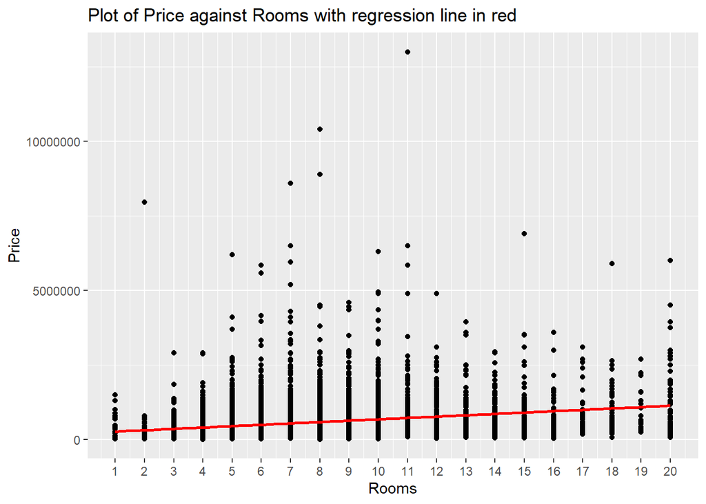

```r
#Rooms
ggplot(data, aes(Rooms,Price)) + geom_point()+ geom_smooth(method = lm, se = F, color= 'red') +
scale_x_continuous(breaks = rep(1:20,len=20)) + ggtitle('Plot of Price against Rooms with regression line in red')
```

```r
lm.log.price_rooms <- lm(log(Price) ~ log(Rooms))
summary(lm.log.price_rooms)
```

```
##
## Call:
## lm(formula = log(Price) ~ log(Rooms))
##
## Residuals:
##     Min      1Q  Median      3Q     Max
## -3.8055 -0.4340  0.0764  0.5004  3.7055
##
## Coefficients:
##             Estimate Std. Error t value            Pr(>|t|)
## (Intercept) 11.76680    0.03351   351.2 <0.0000000000000002 ***
## log(Rooms)   0.60064    0.01777    33.8 <0.0000000000000002 ***
## ---
## Signif. codes:  0 '***' 0.001 '**' 0.01 '*' 0.05 '.' 0.1 ' ' 1
##
## Residual standard error: 0.7945 on 10316 degrees of freedom
## Multiple R-squared:  0.09968,    Adjusted R-squared:  0.0996
## F-statistic:  1142 on 1 and 10316 DF,  p-value: < 0.00000000000000022
```

### 1.5.1 Measures of fit

```r
#r.squared
summary(lm.log.price_rooms)$r.squared
```

```
## [1] 0.09968285
```

```r
#adj.r.squared
summary(lm.log.price_rooms)$adj.r.squared
```

```
## [1] 0.09959558
```

## 1.6 Linear regression of log(Price) against Type

Now we are modelling a linear regression with dependent variable ‘Price’ and the categorical variable “Type” as independent variable. First we visualize the variable ‘Type’ with a boxplot with and one without outliers.

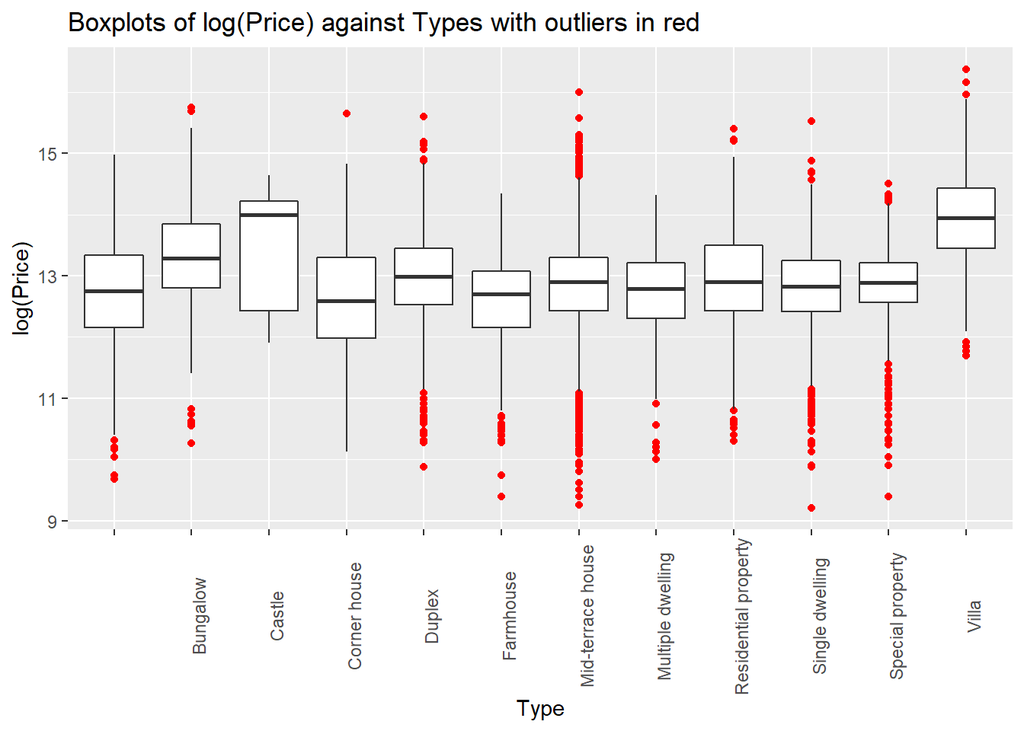

```r
types.box.with_outlier <- ggplot(data, aes(x=Type, y=log(Price))) + geom_boxplot(outlier.colour = 'red')+ theme(axis.text.x = element_text(angle = 90)) + ggtitle('Boxplots of log(Price) against Types with outliers in red')
plot(types.box.with_outlier)
```

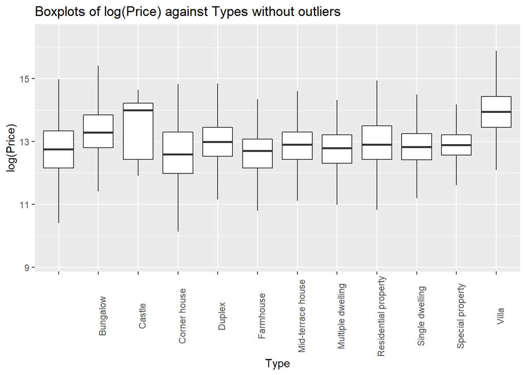

```r
types.box.no_outlier <- ggplot(data, aes(x=Type, y=log(Price))) + geom_boxplot(outlier.shape = NA)+ theme(axis.text.x = element_text(angle = 90)) + ggtitle('Boxplots of log(Price) against Types without outliers')
plot(types.box.no_outlier)
```

```r
lm.log.price_type <- lm(log(Price) ~ Type)
summary(lm.log.price_type)
```

```
##
## Call:
## lm(formula = log(Price) ~ Type)
##
## Residuals:
##     Min      1Q  Median      3Q     Max
## -3.5631 -0.4116  0.0689  0.5015  3.1793
##
## Coefficients:
##                          Estimate Std. Error t value             Pr(>|t|)
## (Intercept)              12.65295    0.04081 310.053 < 0.0000000000000002 ***
## TypeBungalow              0.63769    0.06603   9.658 < 0.0000000000000002 ***
## TypeCastle                0.78868    0.36041   2.188              0.02867 *
## TypeCorner house         -0.02869    0.07014  -0.409              0.68253
## TypeDuplex                0.30148    0.04462   6.757      0.0000000000148 ***
## TypeFarmhouse            -0.10875    0.05279  -2.060              0.03940 *
## TypeMid-terrace house     0.16931    0.04259   3.975      0.0000708585622 ***
## TypeMultiple dwelling     0.05002    0.05794   0.863              0.38802
## TypeResidential property  0.30141    0.05896   5.112      0.0000003245296 ***
## TypeSingle dwelling       0.11287    0.04707   2.398              0.01651 *
## TypeSpecial property      0.15413    0.05879   2.622              0.00876 **
## TypeVilla                 1.28511    0.05771  22.267 < 0.0000000000000002 ***
## ---
## Signif. codes:  0 '***' 0.001 '**' 0.01 '*' 0.05 '.' 0.1 ' ' 1
##
## Residual standard error: 0.8007 on 10306 degrees of freedom
## Multiple R-squared:  0.08637,    Adjusted R-squared:  0.08539
## F-statistic: 88.57 on 11 and 10306 DF,  p-value: < 0.00000000000000022
```

## 1.7 Testing the effect of a categorical variable and post-hoc contrasts

```r
head(data1)
```

```
##     Price              Type Living_space Lot Rooms Bedrooms Bathrooms Floors
## 1  498000 Multiple dwelling       106.00 229     5        3         1      2
## 2  495000 Mid-terrace house       140.93 517     6        3         2     NA
## 3  749000         Farmhouse       162.89  82     5        3         2      4
## 4  259000         Farmhouse       140.00 814     4       NA         2      2
## 5  469000 Multiple dwelling       115.00 244     4        2         1     NA
## 6 1400000 Mid-terrace house       310.00 860     8       NA        NA      3
##   Year_built Furnishing_quality Year_renovated   Condition         Heating
## 1       2005             normal             NA refurbished central heating
## 2       1994              basic             NA refurbished   stove heating
## 3       2013                                NA dilapidated   stove heating
## 4       1900              basic           2000 fixer-upper central heating
## 5       1968            refined           2019 refurbished central heating
## 6       1969              basic             NA  maintained
##      Energy_source Energy_efficiency_class             State              City
## 1      natural gas                       D Baden-Württemberg     Bodenseekreis
## 2                                          Baden-Württemberg  Konstanz (Kreis)
## 3 district heating                       B Baden-Württemberg Esslingen (Kreis)
## 4      electricity                       G Baden-Württemberg  Waldshut (Kreis)
## 5              oil                       F Baden-Württemberg Esslingen (Kreis)
## 6              oil                         Baden-Württemberg         Stuttgart
##                     Place Garages  Garagetype log.price log.living log.rooms
## 1             Bermatingen       2 Parking lot  13.11836   4.663439  1.609438
## 2                   Engen       7 Parking lot  13.11231   4.948263  1.791759
## 3              Ostfildern       1      Garage  13.52649   5.093075  1.609438
## 4 Bonndorf im Schwarzwald       1      Garage  12.46458   4.941642  1.386294
## 5 Leinfelden-Echterdingen       1      Garage  13.05836   4.744932  1.386294
## 6                     Süd       2      Garage  14.15198   5.736572  2.079442
```

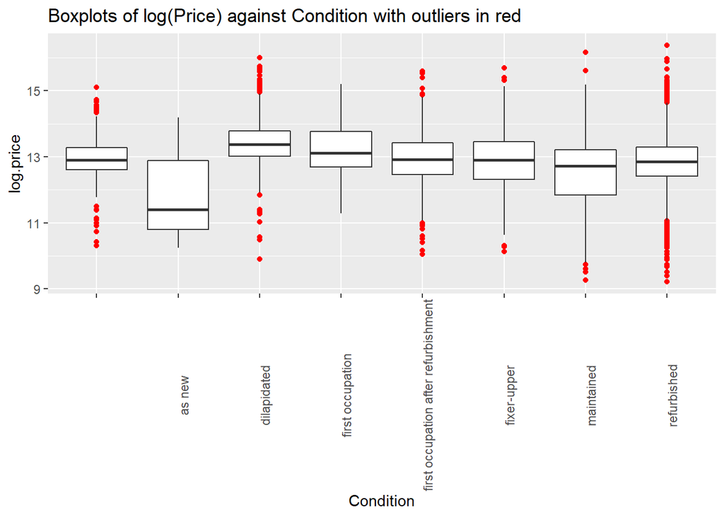

```r
condition.box.with_outlier <- ggplot(data1, aes(x=Condition, y=log.price)) + geom_boxplot(outlier.colour = 'red')+ theme(axis.text.x = element_text(angle = 90)) + ggtitle('Boxplots of log(Price) against Condition with outliers in red')
plot(condition.box.with_outlier)
```

```r
#model
lm.price_condition.1 <- lm(log.price ~ Condition, data = data1)
summary(lm.price_condition.1)
```

```
##
## Call:
## lm(formula = log.price ~ Condition, data = data1)
##
## Residuals:
##     Min      1Q  Median      3Q     Max
## -3.6043 -0.4304  0.0333  0.4884  3.6247
##
## Coefficients:
##                                               Estimate Std. Error t value
## (Intercept)                                   12.95695    0.04213 307.553
## Conditionas new                               -1.01885    0.24696  -4.126
## Conditiondilapidated                           0.47108    0.04838   9.738
## Conditionfirst occupation                      0.19331    0.09330   2.072
## Conditionfirst occupation after refurbishment -0.05091    0.05685  -0.895
## Conditionfixer-upper                          -0.10881    0.05398  -2.016
## Conditionmaintained                           -0.42435    0.04906  -8.649
## Conditionrefurbished                          -0.14229    0.04328  -3.288
##                                                           Pr(>|t|)
## (Intercept)                                   < 0.0000000000000002 ***
## Conditionas new                                          0.0000373 ***
## Conditiondilapidated                          < 0.0000000000000002 ***
## Conditionfirst occupation                                  0.03829 *
## Conditionfirst occupation after refurbishment              0.37055
## Conditionfixer-upper                                       0.04384 *
## Conditionmaintained                           < 0.0000000000000002 ***
## Conditionrefurbished                                       0.00101 **
## ---
## Signif. codes:  0 '***' 0.001 '**' 0.01 '*' 0.05 '.' 0.1 ' ' 1
##
## Residual standard error: 0.8071 on 10310 degrees of freedom
## Multiple R-squared:  0.07146,    Adjusted R-squared:  0.07083
## F-statistic: 113.4 on 7 and 10310 DF,  p-value: < 0.00000000000000022
```

```r
#coefficients
condition.coef.1 <- coef(lm.price_condition.1)
condition.coef.1
```

```
##                                   (Intercept)
##                                   12.95694626
##                               Conditionas new
##                                   -1.01884973
##                          Conditiondilapidated
##                                    0.47108462
##                     Conditionfirst occupation
##                                    0.19330741
## Conditionfirst occupation after refurbishment
##                                   -0.05090966
##                          Conditionfixer-upper
##                                   -0.10881029
##                           Conditionmaintained
##                                   -0.42434950
##                          Conditionrefurbished
##                                   -0.14228677
```

```r
#model without slope, only intercept
lm.price_condition.0 <- lm(log.price ~ 1, data = data1)
summary(lm.price_condition.0)
```

```
##
## Call:
## lm(formula = log.price ~ 1, data = data1)
##
## Residuals:
##     Min      1Q  Median      3Q     Max
## -3.6576 -0.4388  0.0287  0.5166  3.5125
##
## Coefficients:
##              Estimate Std. Error t value            Pr(>|t|)
## (Intercept) 12.867983   0.008243    1561 <0.0000000000000002 ***
## ---
## Signif. codes:  0 '***' 0.001 '**' 0.01 '*' 0.05 '.' 0.1 ' ' 1
##
## Residual standard error: 0.8373 on 10317 degrees of freedom
```

```r
condition.coef.0 <- coef(lm.price_condition.0)
condition.coef.0
```

```
## (Intercept)
##    12.86798
```

```r
#Anova
anova.condition <- anova(lm.price_condition.0, lm.price_condition.1)
anova.condition
```

```
## Analysis of Variance Table
##
## Model 1: log.price ~ 1
## Model 2: log.price ~ Condition
##   Res.Df    RSS Df Sum of Sq      F                Pr(>F)
## 1  10317 7232.5
## 2  10310 6715.7  7    516.86 113.36 < 0.00000000000000022 ***
## ---
## Signif. codes:  0 '***' 0.001 '**' 0.01 '*' 0.05 '.' 0.1 ' ' 1
```

```r
#post-hoc contrasts
library(multcomp)
unique(data1$Condition)
```

```
## [1] refurbished                          dilapidated
## [3] fixer-upper                          maintained
## [5] as new
## [7] first occupation after refurbishment first occupation
## 8 Levels:  as new dilapidated ... refurbished
```

```r
ph.test.1 <- glht(model = lm.price_condition.1, linfct = mcp(Condition = c('refurbished - dilapidated = 0')))
summary(ph.test.1)
```

```
##
##   Simultaneous Tests for General Linear Hypotheses
##
## Multiple Comparisons of Means: User-defined Contrasts
##
##
## Fit: lm(formula = log.price ~ Condition, data = data1)
##
## Linear Hypotheses:
##                                Estimate Std. Error t value            Pr(>|t|)
## refurbished - dilapidated == 0 -0.61337    0.02576  -23.81 <0.0000000000000002
##
## refurbished - dilapidated == 0 ***
## ---
## Signif. codes:  0 '***' 0.001 '**' 0.01 '*' 0.05 '.' 0.1 ' ' 1
## (Adjusted p values reported -- single-step method)
```

## 1.8 Testing categorical variable (Furnishing_quality)and comparing by F-test

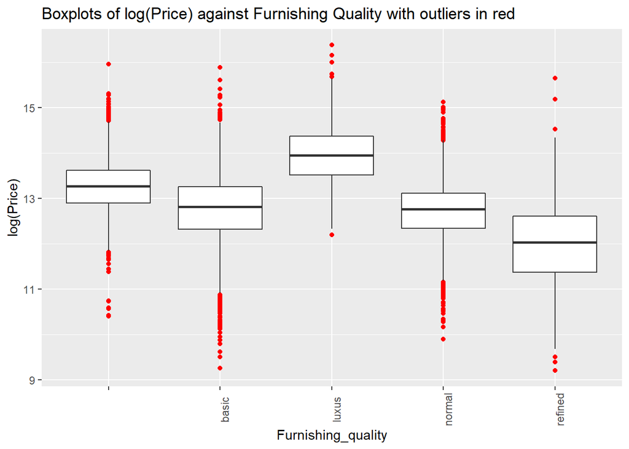

```r
furnish.box.with_outlier <- ggplot(data, aes(x=Furnishing_quality, y=log(Price))) + geom_boxplot(outlier.colour = 'red')+ theme(axis.text.x = element_text(angle = 90)) + ggtitle('Boxplots of log(Price) against Furnishing Quality with outliers in red')
plot(furnish.box.with_outlier)
```

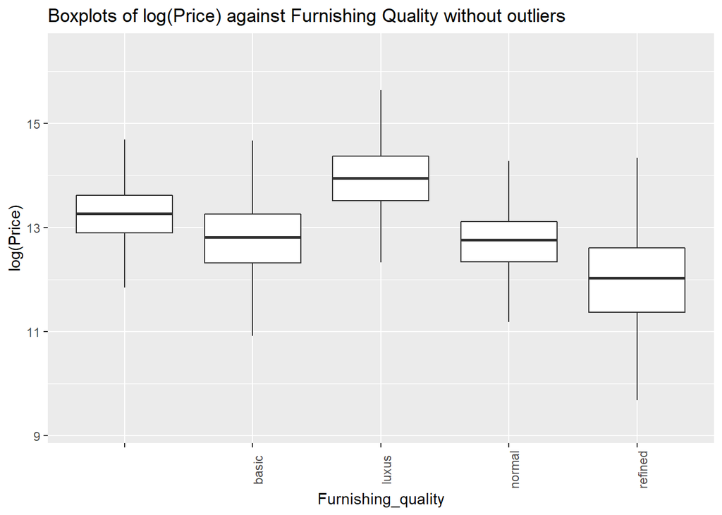

```r
furnish.box.no_outlier <- ggplot(data, aes(x=Furnishing_quality, y=log(Price))) + geom_boxplot(outlier.shape = NA)+ theme(axis.text.x = element_text(angle = 90)) + ggtitle('Boxplots of log(Price) against Furnishing Quality without outliers')
plot(furnish.box.no_outlier)
```

```r
lm.furnishing <- lm(log(Price) ~ Furnishing_quality)
summary(lm.furnishing)
```

```
##
## Call:
## lm(formula = log(Price) ~ Furnishing_quality)
##
## Residuals:
##     Min      1Q  Median      3Q     Max
## -3.4745 -0.3982  0.0292  0.4302  3.6610
##
## Coefficients:
##                           Estimate Std. Error t value            Pr(>|t|)
## (Intercept)               13.29236    0.01391  955.52 <0.0000000000000002 ***
## Furnishing_qualitybasic   -0.55871    0.01977  -28.27 <0.0000000000000002 ***
## Furnishing_qualityluxus    0.68551    0.03569   19.21 <0.0000000000000002 ***
## Furnishing_qualitynormal  -0.57117    0.01834  -31.14 <0.0000000000000002 ***
## Furnishing_qualityrefined -1.29734    0.02777  -46.72 <0.0000000000000002 ***
## ---
## Signif. codes:  0 '***' 0.001 '**' 0.01 '*' 0.05 '.' 0.1 ' ' 1
##
## Residual standard error: 0.7202 on 10313 degrees of freedom
## Multiple R-squared:  0.2605, Adjusted R-squared:  0.2602
## F-statistic: 908.1 on 4 and 10313 DF,  p-value: < 0.00000000000000022
```

```r
lm.furnishing1 <- lm(log(Price) ~ 1)
summary(lm.furnishing1)
```

```
##
## Call:
## lm(formula = log(Price) ~ 1)
##
## Residuals:
##     Min      1Q  Median      3Q     Max
## -3.6576 -0.4388  0.0287  0.5166  3.5125
##
## Coefficients:
##              Estimate Std. Error t value            Pr(>|t|)
## (Intercept) 12.867983   0.008243    1561 <0.0000000000000002 ***
## ---
## Signif. codes:  0 '***' 0.001 '**' 0.01 '*' 0.05 '.' 0.1 ' ' 1
##
## Residual standard error: 0.8373 on 10317 degrees of freedom
```

```r
anova.furnishing <- anova(lm.furnishing1, lm.furnishing)
summary(anova.furnishing)
```

```
##      Res.Df           RSS             Df      Sum of Sq          F
##  Min.   :10313   Min.   :5349   Min.   :4   Min.   :1884   Min.   :908.1
##  1st Qu.:10314   1st Qu.:5820   1st Qu.:4   1st Qu.:1884   1st Qu.:908.1
##  Median :10315   Median :6291   Median :4   Median :1884   Median :908.1
##  Mean   :10315   Mean   :6291   Mean   :4   Mean   :1884   Mean   :908.1
##  3rd Qu.:10316   3rd Qu.:6762   3rd Qu.:4   3rd Qu.:1884   3rd Qu.:908.1
##  Max.   :10317   Max.   :7233   Max.   :4   Max.   :1884   Max.   :908.1
##                                 NA's   :1   NA's   :1      NA's   :1
##      Pr(>F)
##  Min.   :0
##  1st Qu.:0
##  Median :0
##  Mean   :0
##  3rd Qu.:0
##  Max.   :0
##  NA's   :1
```

### 1.8.1 Adding more categorical variables to the testing above

```r
lm.furnishing2 <- update(lm.furnishing,. ~ . + Type + Condition)
formula(lm.furnishing2)
```

```
## log(Price) ~ Furnishing_quality + Type + Condition
```

```r
drop1(lm.furnishing2, test = "F")
```

```
## Single term deletions
##
## Model:
## log(Price) ~ Furnishing_quality + Type + Condition
##                    Df Sum of Sq    RSS     AIC F value                Pr(>F)
## <none>                          4969.7 -7491.5
## Furnishing_quality  4   1174.81 6144.5 -5310.1 608.414 < 0.00000000000000022
## Type               11    314.25 5284.0 -6880.9  59.181 < 0.00000000000000022
## Condition           7     78.09 5047.8 -7344.7  23.110 < 0.00000000000000022
##
## <none>
## Furnishing_quality ***
## Type               ***
## Condition          ***
## ---
## Signif. codes:  0 '***' 0.001 '**' 0.01 '*' 0.05 '.' 0.1 ' ' 1
```

## 1.9 Linear regression of log(Price) against log(Living_space) including the Type-Living_space interaction

```r
lm.interact <- lm(log(Price) ~ log(Living_space) * Type) # lm(y ~ x1 * x2) equivalent to lm(y ~ x1 + x2 + x1:x2)
summary(lm.interact)
```

```
##
## Call:
## lm(formula = log(Price) ~ log(Living_space) * Type)
##
## Residuals:
##     Min      1Q  Median      3Q     Max
## -4.0574 -0.3835  0.0672  0.4576  2.7139
##
## Coefficients:
##                                            Estimate Std. Error t value
## (Intercept)                                 7.73609    0.27923  27.705
## log(Living_space)                           0.94614    0.05331  17.749
## TypeBungalow                                0.92173    0.48628   1.895
## TypeCastle                                 -1.04467    5.02138  -0.208
## TypeCorner house                           -0.80053    0.58144  -1.377
## TypeDuplex                                  1.34421    0.35134   3.826
## TypeFarmhouse                               0.63145    0.53470   1.181
## TypeMid-terrace house                      -0.68139    0.31354  -2.173
## TypeMultiple dwelling                       0.24793    0.69059   0.359
## TypeResidential property                   -0.31372    0.45320  -0.692
## TypeSingle dwelling                        -0.75763    0.42213  -1.795
## TypeSpecial property                       -0.77518    0.45681  -1.697
## TypeVilla                                   0.06219    0.60861   0.102
## log(Living_space):TypeBungalow             -0.11718    0.08861  -1.322
## log(Living_space):TypeCastle                0.12151    0.79328   0.153
## log(Living_space):TypeCorner house          0.12396    0.10936   1.133
## log(Living_space):TypeDuplex               -0.24967    0.06560  -3.806
## log(Living_space):TypeFarmhouse            -0.08080    0.10831  -0.746
## log(Living_space):TypeMid-terrace house     0.18009    0.06011   2.996
## log(Living_space):TypeMultiple dwelling     0.01967    0.13964   0.141
## log(Living_space):TypeResidential property  0.09284    0.08538   1.087
## log(Living_space):TypeSingle dwelling       0.23218    0.08354   2.779
## log(Living_space):TypeSpecial property      0.25164    0.09095   2.767
## log(Living_space):TypeVilla                 0.11600    0.10750   1.079
##                                                        Pr(>|t|)
## (Intercept)                                < 0.0000000000000002 ***
## log(Living_space)                          < 0.0000000000000002 ***
## TypeBungalow                                           0.058061 .
## TypeCastle                                             0.835198
## TypeCorner house                                       0.168607
```

[output cut: 10 more lines]

```
## log(Living_space):TypeCorner house                     0.257038
## log(Living_space):TypeDuplex                           0.000142 ***
## log(Living_space):TypeFarmhouse                        0.455705
## log(Living_space):TypeMid-terrace house                0.002741 **
## log(Living_space):TypeMultiple dwelling                0.887975
## log(Living_space):TypeResidential property             0.276883
## log(Living_space):TypeSingle dwelling                  0.005460 **
## log(Living_space):TypeSpecial property                 0.005673 **
## log(Living_space):TypeVilla                            0.280593
## ---
## Signif. codes:  0 '***' 0.001 '**' 0.01 '*' 0.05 '.' 0.1 ' ' 1
##
## Residual standard error: 0.6879 on 10294 degrees of freedom
## Multiple R-squared:  0.3264, Adjusted R-squared:  0.3249
## F-statistic: 216.9 on 23 and 10294 DF,  p-value: < 0.00000000000000022
```

```r
#coefficients
interact.coefs <- coef(lm.interact)
interact.coefs
```

```
##                                (Intercept)
##                                 7.73608549
##                          log(Living_space)
##                                 0.94613962
##                               TypeBungalow
##                                 0.92172518
##                                 TypeCastle
##                                -1.04467031
##                           TypeCorner house
##                                -0.80052753
##                                 TypeDuplex
##                                 1.34420839
##                              TypeFarmhouse
##                                 0.63144756
##                      TypeMid-terrace house
##                                -0.68139164
##                      TypeMultiple dwelling
##                                 0.24793247
##                   TypeResidential property
##                                -0.31371529
##                        TypeSingle dwelling
##                                -0.75763067
##                       TypeSpecial property
##                                -0.77518375
##                                  TypeVilla
##                                 0.06219264
##             log(Living_space):TypeBungalow
##                                -0.11718366
##               log(Living_space):TypeCastle
##                                 0.12151270
##         log(Living_space):TypeCorner house
##                                 0.12396267
##               log(Living_space):TypeDuplex
##                                -0.24967456
##            log(Living_space):TypeFarmhouse
##                                -0.08079852
##    log(Living_space):TypeMid-terrace house
##                                 0.18008764
##    log(Living_space):TypeMultiple dwelling
##                                 0.01967192
## log(Living_space):TypeResidential property
##                                 0.09283769
##      log(Living_space):TypeSingle dwelling
##                                 0.23217929
##     log(Living_space):TypeSpecial property
##                                 0.25164379
##                log(Living_space):TypeVilla
##                                 0.11599769
```

```r
#p-values
summary(lm.interact)$coefficients
```

```
##                                               Estimate Std. Error    t value
## (Intercept)                                 7.73608549 0.27923294 27.7047740
## log(Living_space)                           0.94613962 0.05330683 17.7489368
## TypeBungalow                                0.92172518 0.48628378  1.8954471
## TypeCastle                                 -1.04467031 5.02137529 -0.2080447
## TypeCorner house                           -0.80052753 0.58144468 -1.3767905
## TypeDuplex                                  1.34420839 0.35134194  3.8259264
## TypeFarmhouse                               0.63144756 0.53470359  1.1809301
## TypeMid-terrace house                      -0.68139164 0.31354101 -2.1732138
## TypeMultiple dwelling                       0.24793247 0.69059454  0.3590131
## TypeResidential property                   -0.31371529 0.45319947 -0.6922234
## TypeSingle dwelling                        -0.75763067 0.42213336 -1.7947662
## TypeSpecial property                       -0.77518375 0.45681072 -1.6969474
## TypeVilla                                   0.06219264 0.60860899  0.1021882
## log(Living_space):TypeBungalow             -0.11718366 0.08861463 -1.3223963
## log(Living_space):TypeCastle                0.12151270 0.79327905  0.1531778
## log(Living_space):TypeCorner house          0.12396267 0.10936453  1.1334816
## log(Living_space):TypeDuplex               -0.24967456 0.06560013 -3.8060072
## log(Living_space):TypeFarmhouse            -0.08079852 0.10831388 -0.7459665
## log(Living_space):TypeMid-terrace house     0.18008764 0.06010723  2.9961062
## log(Living_space):TypeMultiple dwelling     0.01967192 0.13964491  0.1408710
## log(Living_space):TypeResidential property  0.09283769 0.08537544  1.0874051
## log(Living_space):TypeSingle dwelling       0.23217929 0.08354340  2.7791456
## log(Living_space):TypeSpecial property      0.25164379 0.09095466  2.7666950
## log(Living_space):TypeVilla                 0.11599769 0.10750039  1.0790443
##                                                                                                                                                                                                               Pr(>|t|)
## (Intercept)                                0.0000000000000000000000000000000000000000000000000000000000000000000000000000000000000000000000000000000000000000000000000000000000000000000000000000000000000000005288402
## log(Living_space)                          0.0000000000000000000000000000000000000000000000000000000000000000000018924286248276228869155679568336836382513865828514099121093750000000000000000000000000000000000000000
## TypeBungalow                               0.0580611813091401196551544217072660103440284729003906250000000000000000000000000000000000000000000000000000000000000000000000000000000000000000000000000000000000000000000
## TypeCastle                                 0.8351982133890091253292098372185137122869491577148437500000000000000000000000000000000000000000000000000000000000000000000000000000000000000000000000000000000000000000000
## TypeCorner house                           0.1686069563807466864524542415892938151955604553222656250000000000000000000000000000000000000000000000000000000000000000000000000000000000000000000000000000000000000000000
## TypeDuplex                                 0.0001310513332601861058359510314730300706287380307912826538085937500000000000000000000000000000000000000000000000000000000000000000000000000000000000000000000000000000000
## TypeFarmhouse                              0.2376577736645028859907569085407885722815990447998046875000000000000000000000000000000000000000000000000000000000000000000000000000000000000000000000000000000000000000000
```

[output cut: 17 more lines]

```r
#Confidence Intervals
lm.interact.CI <- confint(lm.interact)
lm.interact.CI
```

```
##                                                   2.5 %      97.5 %
## (Intercept)                                  7.18873463  8.28343635
## log(Living_space)                            0.84164786  1.05063138
## TypeBungalow                                -0.03148560  1.87493595
## TypeCastle                                 -10.88754235  8.79820173
## TypeCorner house                            -1.94027217  0.33921710
## TypeDuplex                                   0.65550987  2.03290692
## TypeFarmhouse                               -0.41667545  1.67957057
## TypeMid-terrace house                       -1.29599299 -0.06679028
## TypeMultiple dwelling                       -1.10576712  1.60163207
## TypeResidential property                    -1.20207438  0.57464379
## TypeSingle dwelling                         -1.58509414  0.06983281
## TypeSpecial property                        -1.67062159  0.12025410
## TypeVilla                                   -1.13079934  1.25518461
## log(Living_space):TypeBungalow              -0.29088557  0.05651824
## log(Living_space):TypeCastle                -1.43346849  1.67649390
## log(Living_space):TypeCorner house          -0.09041307  0.33833842
## log(Living_space):TypeDuplex                -0.37826357 -0.12108555
## log(Living_space):TypeFarmhouse             -0.29311479  0.13151774
## log(Living_space):TypeMid-terrace house      0.06226578  0.29790949
## log(Living_space):TypeMultiple dwelling     -0.25405926  0.29340310
## log(Living_space):TypeResidential property  -0.07451478  0.26019016
## log(Living_space):TypeSingle dwelling        0.06841797  0.39594061
## log(Living_space):TypeSpecial property       0.07335498  0.42993261
## log(Living_space):TypeVilla                 -0.09472399  0.32671936
```

### 1.9.1 Measures of fit

```r
#r.squared
summary(lm.interact)$r.squared
```

```
## [1] 0.3263949
```

```r
#adj.r.squared
summary(lm.interact)$adj.r.squared
```

```
## [1] 0.3248899
```

## 1.10 Fitted values

**The function fitted() can be used to extract the predicted values for the existing observations**

```r
attach(data)
#lm.log.price_living
fitted.price_living <- fitted(lm.log.price_living)
str(fitted.price_living)
```

```
##  Named num [1:10318] 12.4 12.6 12.8 12.6 12.5 ...
##  - attr(*, "names")= chr [1:10318] "1" "2" "3" "4" ...
```

```r
head(fitted.price_living)
```

```
##        1        2        3        4        5        6
## 12.38539 12.64253 12.77327 12.63655 12.45896 13.35422
```

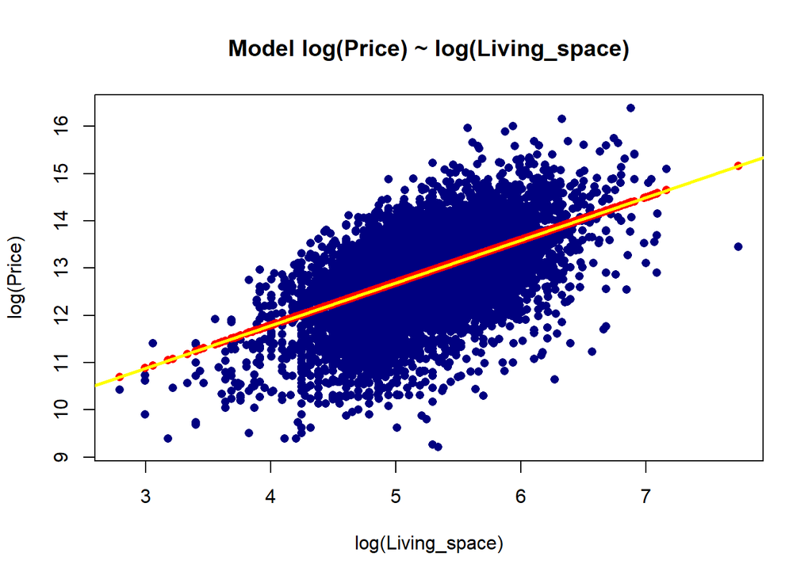

```r
plot(log(Price)~ log(Living_space), main = 'Model log(Price) ~ log(Living_space)', col = 'navy', pch = 16)
points(fitted.price_living ~ log(Living_space), col = 'red', pch = 16)
abline(lm.log.price_living, col = 'yellow', lwd = 2.5)
```

```r
#lm.log.price_rooms
fitted.price_rooms <- fitted(lm.log.price_rooms)
str(fitted.price_rooms)
```

```
##  Named num [1:10318] 12.7 12.8 12.7 12.6 12.6 ...
##  - attr(*, "names")= chr [1:10318] "1" "2" "3" "4" ...
```

```r
head(fitted.price_rooms)
```

```
##        1        2        3        4        5        6
## 12.73350 12.84301 12.73350 12.59947 12.59947 13.01580
```

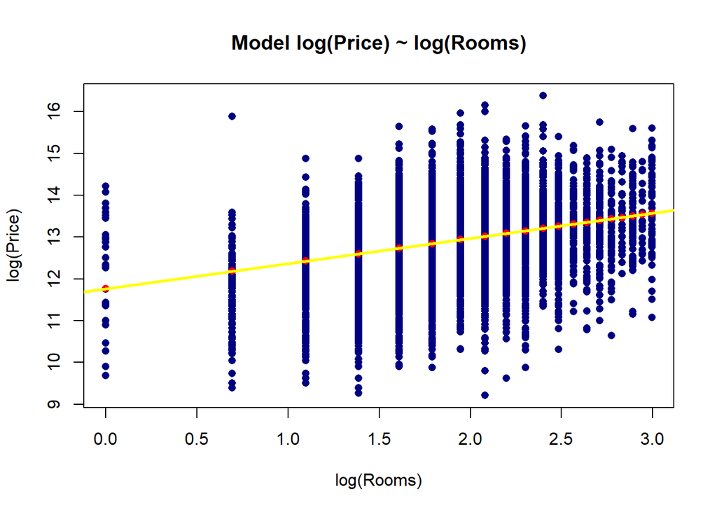

```r
plot(log(Price)~ log(Rooms), main = 'Model log(Price) ~ log(Rooms)', col = 'navy', pch = 16)
points(fitted.price_rooms ~ log(Rooms), col = 'red', pch = 16)
abline(lm.log.price_rooms, col = 'yellow', lwd = 2.5)
```

## 1.11 Residuals of model log(Price) ~ log(Living_space)

```r
attach(data1)
resid.price_living <- resid(lm.log.price_living)
length(resid.price_living)
```

```
## [1] 10318
```

```r
head(resid.price_living)
```

```
##          1          2          3          4          5          6
##  0.7329643  0.4697818  0.7532264 -0.1719706  0.5993948  0.7977636
```

```r
set.seed(100)
id <- sample(x = 1:10318, size = 5)
resid.price_living[id]
```

```
##       3786        503       3430       3696       4090
##  0.5106768 -0.3315001  0.4470366 -0.9261093  1.0834033
```

```r
fitted.price_living[id]
```

```
##     3786      503     3430     3696     4090
## 13.77484 12.69884 13.46378 12.41883 13.03221
```

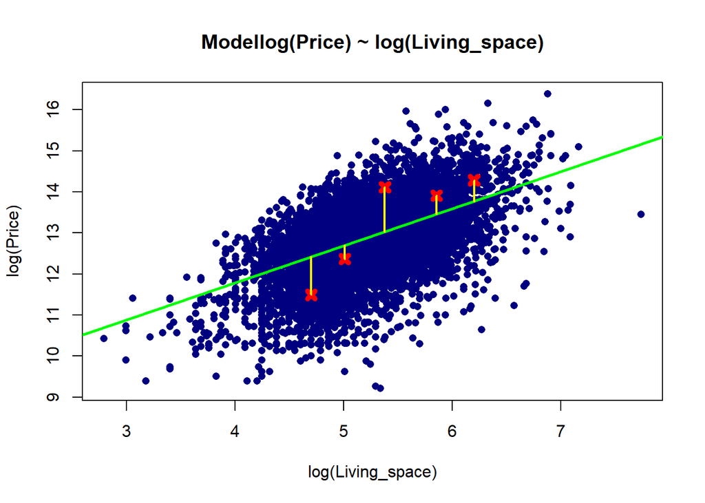

```r
plot(log(Price) ~ log(Living_space), main = 'Modellog(Price) ~ log(Living_space)', col = 'navy', pch = 16)
abline(lm.log.price_living, col = 'green', lwd = 2.5)

points(log(Price) ~ log(Living_space), data = data1[id, ], col = 'red', pch = 4, lwd = 5)
segments(x0 = data1[id, 'log.living'], x1 = data1[id, 'log.living'],
         y0 = fitted.price_living[id], y1 = data1[id, 'log.price'], col = 'yellow', lwd = 2)
```

## 1.12 Residuals of model log(Price) ~ log(Rooms)

```r
attach(data1)
resid.price_rooms <- resid(lm.log.price_rooms)
length(resid.price_rooms)
```

```
## [1] 10318
```

```r
head(resid.price_rooms)
```

```
##          1          2          3          4          5          6
##  0.3848596  0.2693073  0.7929985 -0.1348829  0.4588918  1.1361829
```

```r
set.seed(100)
id <- sample(x = 1:10318, size = 5)
resid.price_rooms[id]
```

```
##       3786        503       3430       3696       4090
##  0.7501601 -0.4756650  0.7609914 -1.2407730  1.2726094
```

```r
fitted.price_rooms[id]
```

```
##     3786      503     3430     3696     4090
## 13.53535 12.84301 13.14983 12.73350 12.84301
```

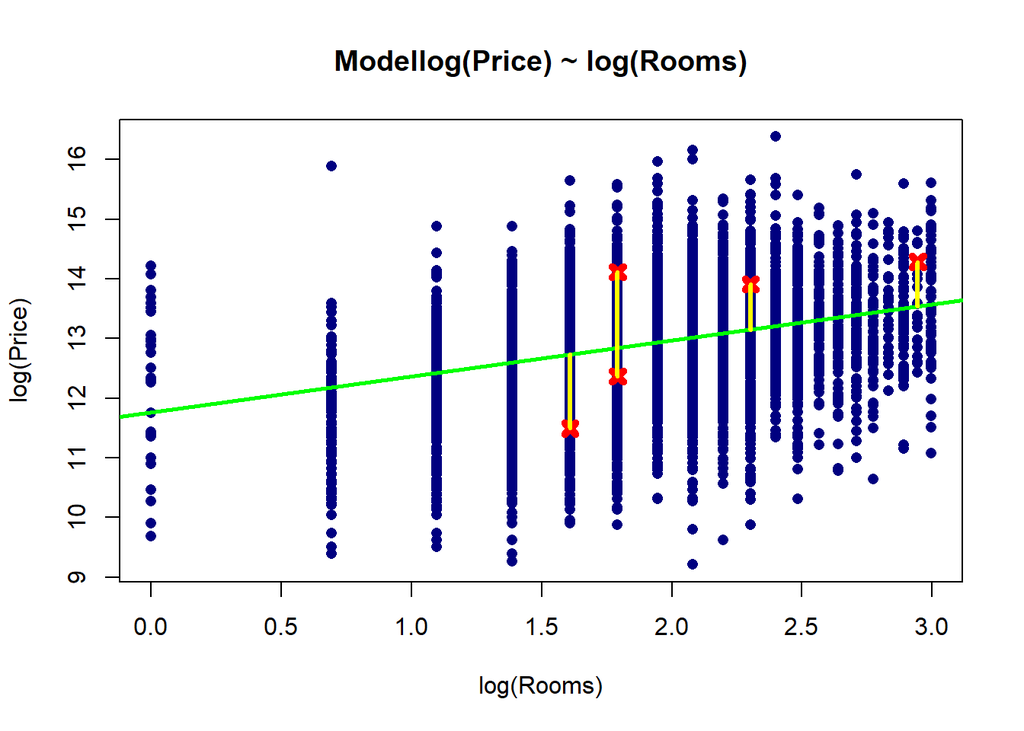

```r
plot(log(Price) ~ log(Rooms), main = 'Modellog(Price) ~ log(Rooms)', col = 'navy', pch = 16)
abline(lm.log.price_rooms, col = 'green', lwd = 2.5)

points(log(Price) ~ log(Rooms), data = data1[id, ], col = 'red', pch = 4, lwd = 5)
segments(x0 = data1[id, 'log.rooms'], x1 = data1[id, 'log.rooms'],
         y0 = fitted.price_rooms[id], y1 = data1[id, 'log.price'], col = 'yellow', lwd = 3)
```

## 1.13 Predicting values using splitted data set 80:20 ratio

```r
#split dataset
split80 <- round(nrow(data1)* 0.80)
train <- data1[1:split80,]
test <- data1[(split80 + 1):nrow(data1),]
dim(train)
```

```
## [1] 8254   23
```

```r
dim(test)
```

```
## [1] 2064   23
```

```r
#linear regression model
lm.train <- lm(log.price ~ log.living, data = train)
summary(lm.train)
```

```
##
## Call:
## lm(formula = log.price ~ log.living, data = train)
##
## Residuals:
##     Min      1Q  Median      3Q     Max
## -3.8765 -0.3774  0.0557  0.4283  2.6734
##
## Coefficients:
##             Estimate Std. Error t value            Pr(>|t|)
## (Intercept)  8.45284    0.07981  105.91 <0.0000000000000002 ***
## log.living   0.86819    0.01524   56.96 <0.0000000000000002 ***
## ---
## Signif. codes:  0 '***' 0.001 '**' 0.01 '*' 0.05 '.' 0.1 ' ' 1
##
## Residual standard error: 0.6563 on 8252 degrees of freedom
## Multiple R-squared:  0.2822, Adjusted R-squared:  0.2821
## F-statistic:  3245 on 1 and 8252 DF,  p-value: < 0.00000000000000022
```

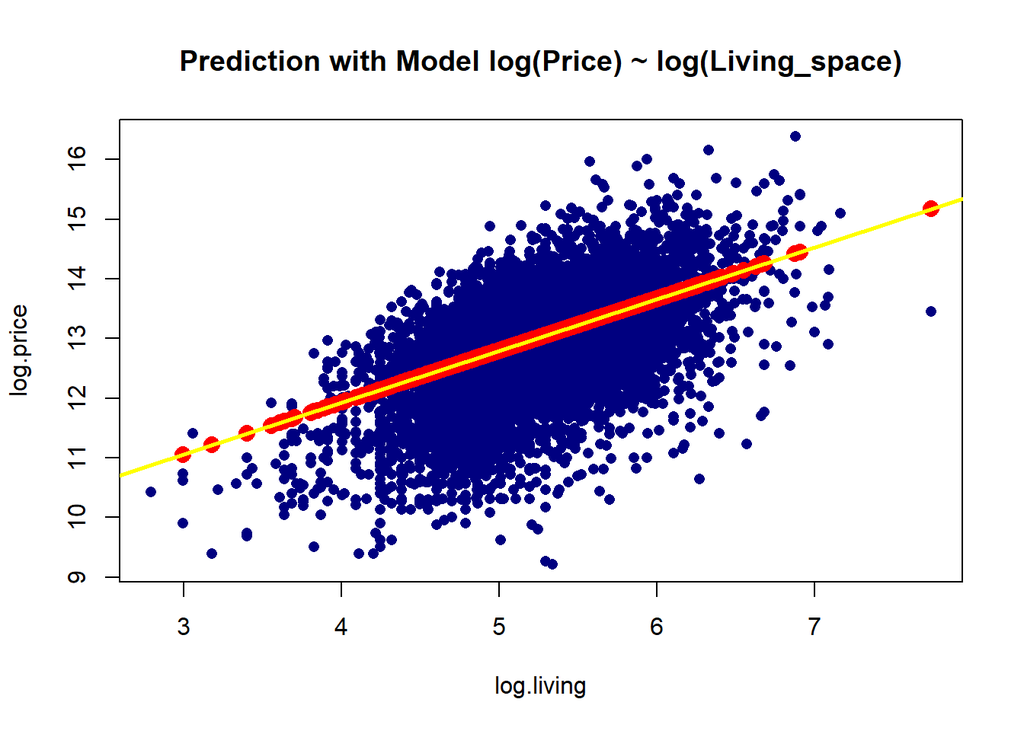

```r
#predictions
pred.new.living <- predict(object = lm.train, newdata = test)
pred.new.living.CI <- predict(object = lm.train, interval = 'prediction', newdata = test)

#display predictions
plot(log.price ~log.living, data = data1, main = 'Prediction with Model log(Price) ~ log(Living_space)', col = 'navy', pch = 16)
points(x = test$log.living, y= pred.new.living, col = 'red', pch = 16, cex = 1.5)
abline(lm.train, col = 'yellow', lwd = 2.5)
```

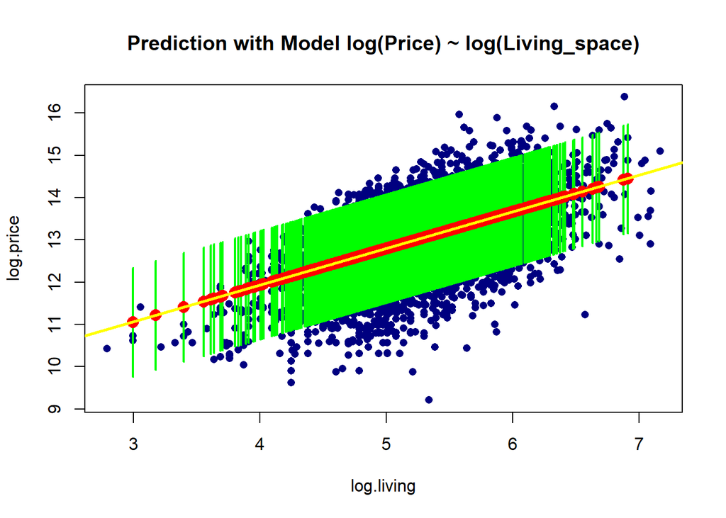

```r
plot(log.price ~ log.living, data = train, main = 'Prediction with Model log(Price) ~ log(Living_space)', col = 'navy', pch = 16)
segments(x0 = test$log.living, x1 = test$log.living,
         y0 = pred.new.living.CI[, 'lwr'], y1 = pred.new.living.CI[, 'upr'], lwd = 2, col = 'green')
points(x = test$log.living, y= pred.new.living.CI[,'fit'], col = 'red', pch = 16, cex =1.5)
abline(lm.train, col = 'yellow', lwd = 2.5)
```

# 2 Week 2 - Non-linearity

Polynomials Graphical analysis

```r
library(mgcv)
attach(data)
library(ggplot2)
```

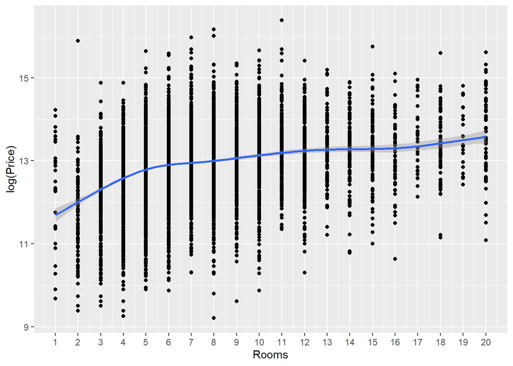

```r
#log(Price) ~ Rooms
gg.PriceRooms <- ggplot(data,
mapping = aes(y = log(Price),
x = Rooms)) +
geom_point()
gg.PriceRooms +
geom_smooth() +
scale_x_continuous(breaks = rep(1:20,len=20))
```

```r
gam.1 <- gam(log(Price) ~ s(Rooms))
summary(gam.1)
```

```
##
## Family: gaussian
## Link function: identity
##
## Formula:
## log(Price) ~ s(Rooms)
##
## Parametric coefficients:
##              Estimate Std. Error t value            Pr(>|t|)
## (Intercept) 12.867983   0.007797    1650 <0.0000000000000002 ***
## ---
## Signif. codes:  0 '***' 0.001 '**' 0.01 '*' 0.05 '.' 0.1 ' ' 1
##
## Approximate significance of smooth terms:
##            edf Ref.df     F             p-value
## s(Rooms) 7.242  8.188 148.3 <0.0000000000000002 ***
## ---
## Signif. codes:  0 '***' 0.001 '**' 0.01 '*' 0.05 '.' 0.1 ' ' 1
##
## R-sq.(adj) =  0.105   Deviance explained = 10.6%
## GCV = 0.62784  Scale est. = 0.62734   n = 10318
```

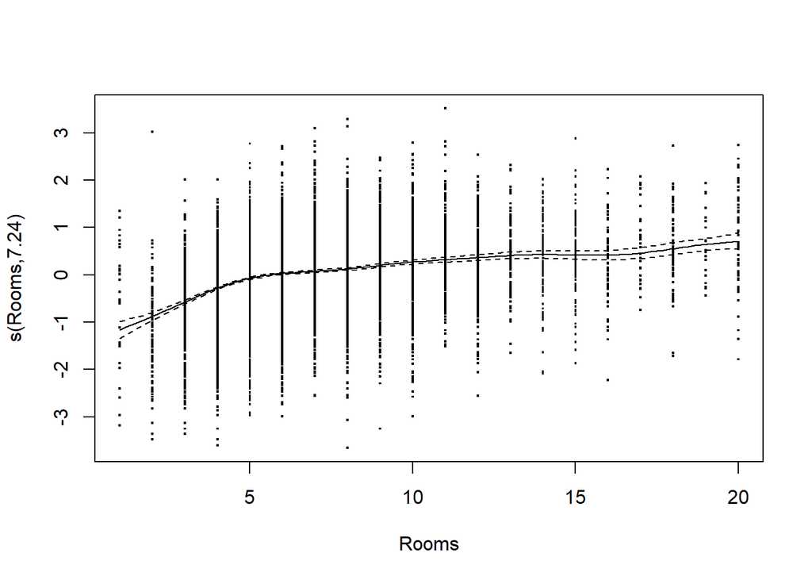

```r
plot(gam.1, residuals = TRUE, cex = 2)
```

log(Prices) ~ log(Rooms)

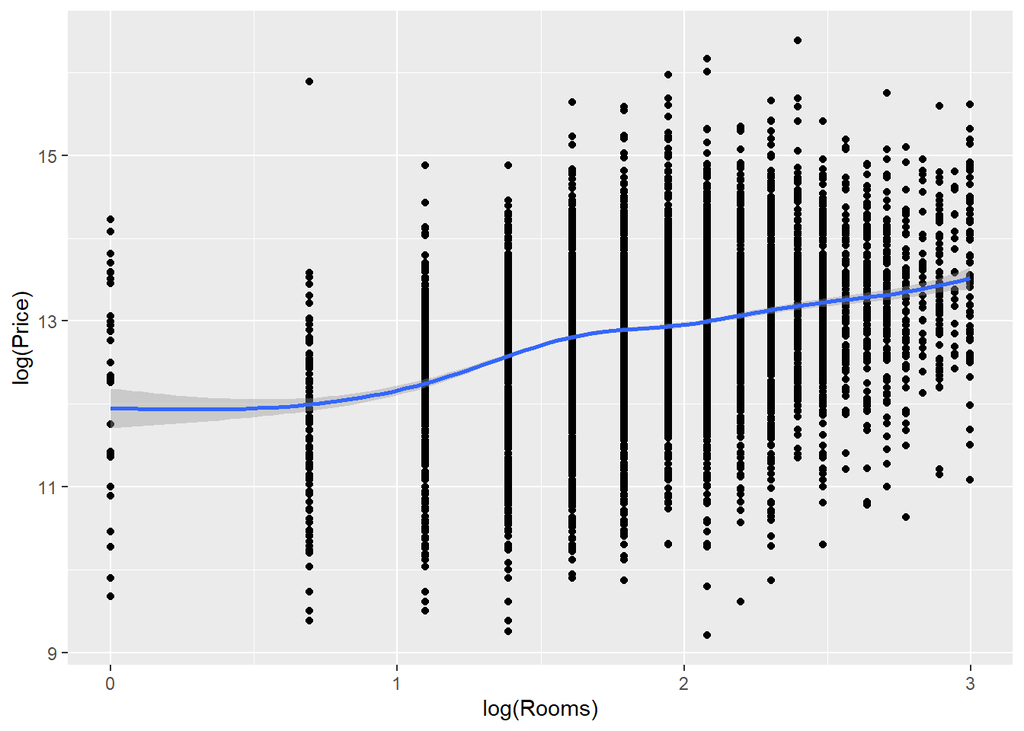

```r
#log(Rooms)
gg.PriceRooms <- ggplot(data,
mapping = aes(y = log(Price),
x = log(Rooms))) +
geom_point()
gg.PriceRooms +
geom_smooth()
```

```r
gam.2 <- gam(log(Price) ~ s(Rooms))
summary(gam.2)
```

```
##
## Family: gaussian
## Link function: identity
##
## Formula:
## log(Price) ~ s(Rooms)
##
## Parametric coefficients:
##              Estimate Std. Error t value            Pr(>|t|)
## (Intercept) 12.867983   0.007797    1650 <0.0000000000000002 ***
## ---
## Signif. codes:  0 '***' 0.001 '**' 0.01 '*' 0.05 '.' 0.1 ' ' 1
##
## Approximate significance of smooth terms:
##            edf Ref.df     F             p-value
## s(Rooms) 7.242  8.188 148.3 <0.0000000000000002 ***
## ---
## Signif. codes:  0 '***' 0.001 '**' 0.01 '*' 0.05 '.' 0.1 ' ' 1
##
## R-sq.(adj) =  0.105   Deviance explained = 10.6%
## GCV = 0.62784  Scale est. = 0.62734   n = 10318
```

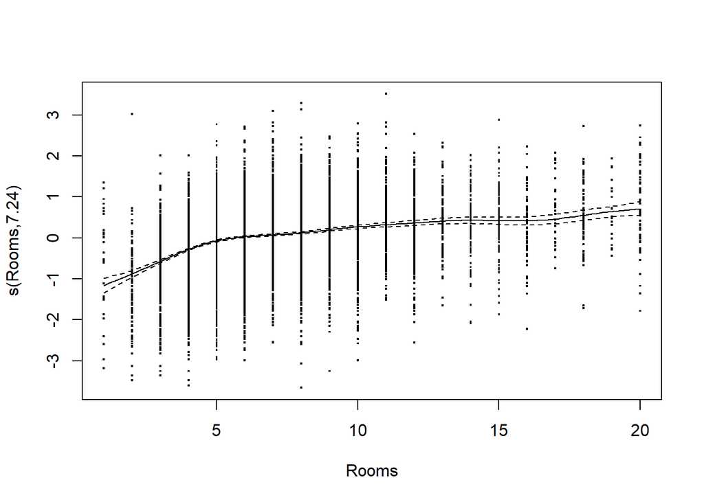

```r
plot(gam.2, residuals = TRUE, cex = 2)
```

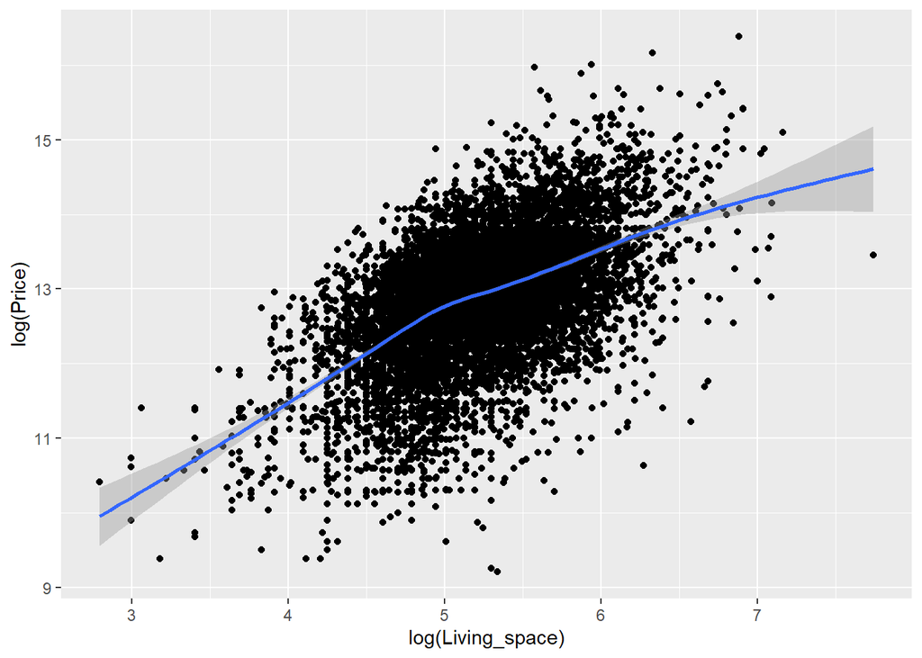

```r
gg.PriceLiving <- ggplot(data,
mapping = aes(y = log(Price),
x = log(Living_space))) +
geom_point()
gg.PriceLiving +
geom_smooth()
```

```r
gam.3 <- gam(log(Price) ~ log(Living_space) +
s(Rooms) + s(Garages),
data = data)
summary(gam.3)
```

```
##
## Family: gaussian
## Link function: identity
##
## Formula:
## log(Price) ~ log(Living_space) + s(Rooms) + s(Garages)
##
## Parametric coefficients:
##                   Estimate Std. Error t value            Pr(>|t|)
## (Intercept)        6.43386    0.13256   48.53 <0.0000000000000002 ***
## log(Living_space)  1.24718    0.02536   49.18 <0.0000000000000002 ***
## ---
## Signif. codes:  0 '***' 0.001 '**' 0.01 '*' 0.05 '.' 0.1 ' ' 1
##
## Approximate significance of smooth terms:
##              edf Ref.df      F              p-value
## s(Rooms)   8.268  8.825 49.855 < 0.0000000000000002 ***
## s(Garages) 8.762  8.972  2.766              0.00351 **
## ---
## Signif. codes:  0 '***' 0.001 '**' 0.01 '*' 0.05 '.' 0.1 ' ' 1
##
## R-sq.(adj) =  0.304   Deviance explained = 30.6%
## GCV = 0.42664  Scale est. = 0.42568   n = 8437
```

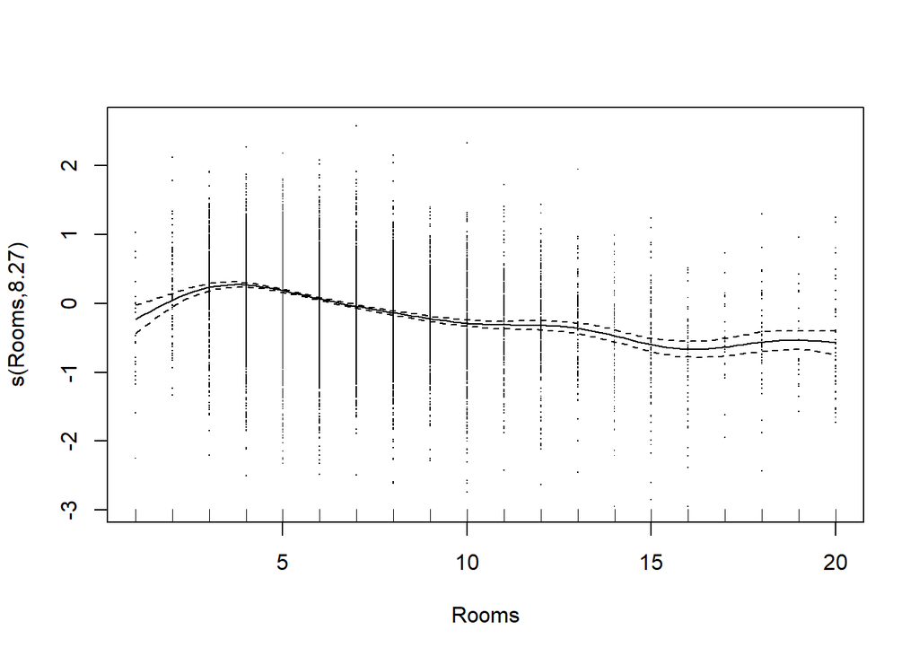

```r
plot(gam.3, residuals = TRUE, select = 1)
```

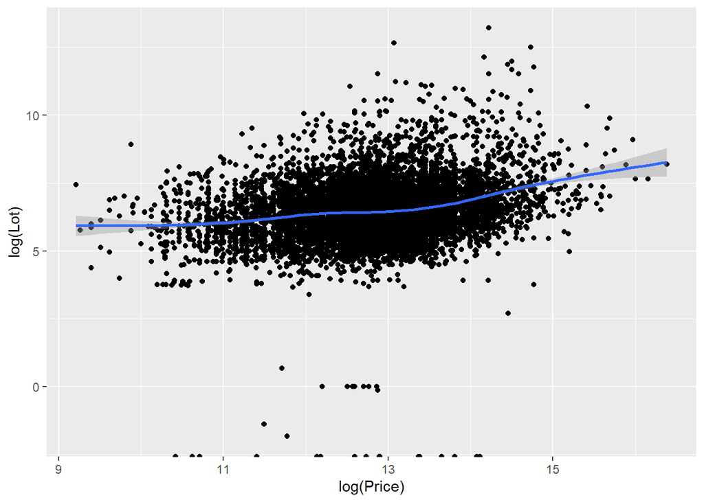

```r
gg.LotPrice <- ggplot(data = data,
mapping = aes(y = log(Lot),
x = log(Price))) +
geom_point()
gg.LotPrice +
geom_smooth(method = 'gam')
```

# 3 Week 3 - Generalised Linear Models

## 3.1 GLM - Possion Model

```r
glm.rooms <- glm(Rooms ~ Type,
family = "poisson",
data = data)

summary(glm.rooms)
```

```
##
## Call:
## glm(formula = Rooms ~ Type, family = "poisson", data = data)
##
## Deviance Residuals:
##     Min       1Q   Median       3Q      Max
## -3.6463  -0.6320  -0.0781   0.3702   4.4559
##
## Coefficients:
##                          Estimate Std. Error z value             Pr(>|z|)
## (Intercept)               2.02917    0.01848 109.821 < 0.0000000000000002 ***
## TypeBungalow              0.17457    0.02838   6.152       0.000000000766 ***
## TypeCastle                0.55104    0.12447   4.427       0.000009550749 ***
## TypeCorner house          0.01343    0.03162   0.425                0.671
## TypeDuplex                0.26787    0.01981  13.522 < 0.0000000000000002 ***
## TypeFarmhouse            -0.43417    0.02638 -16.456 < 0.0000000000000002 ***
## TypeMid-terrace house    -0.22653    0.01948 -11.626 < 0.0000000000000002 ***
## TypeMultiple dwelling    -0.38499    0.02917 -13.197 < 0.0000000000000002 ***
## TypeResidential property  0.04744    0.02637   1.799                0.072 .
## TypeSingle dwelling      -0.38432    0.02252 -17.066 < 0.0000000000000002 ***
## TypeSpecial property     -0.47841    0.03056 -15.655 < 0.0000000000000002 ***
## TypeVilla                 0.14646    0.02522   5.806       0.000000006387 ***
## ---
## Signif. codes:  0 '***' 0.001 '**' 0.01 '*' 0.05 '.' 0.1 ' ' 1
##
## (Dispersion parameter for poisson family taken to be 1)
##
##     Null deviance: 13951.1  on 10317  degrees of freedom
## Residual deviance:  9350.9  on 10306  degrees of freedom
## AIC: 47557
##
## Number of Fisher Scoring iterations: 4
```

```r
set.seed(99)
sim.data.rooms.Poisson <- simulate(glm.rooms)
##
NROW(sim.data.rooms.Poisson)
```

```
## [1] 10318
```

```r
head(sim.data.rooms.Poisson)
```

```
##   sim_1
## 1     5
## 2     3
## 3     6
## 4    11
## 5     5
## 6    11
```

```r
tail(sim.data.rooms.Poisson)
```

```
##       sim_1
## 10313     5
## 10314     4
## 10315     6
## 10316    10
## 10317     6
## 10318     4
```

Visualisierung ;)

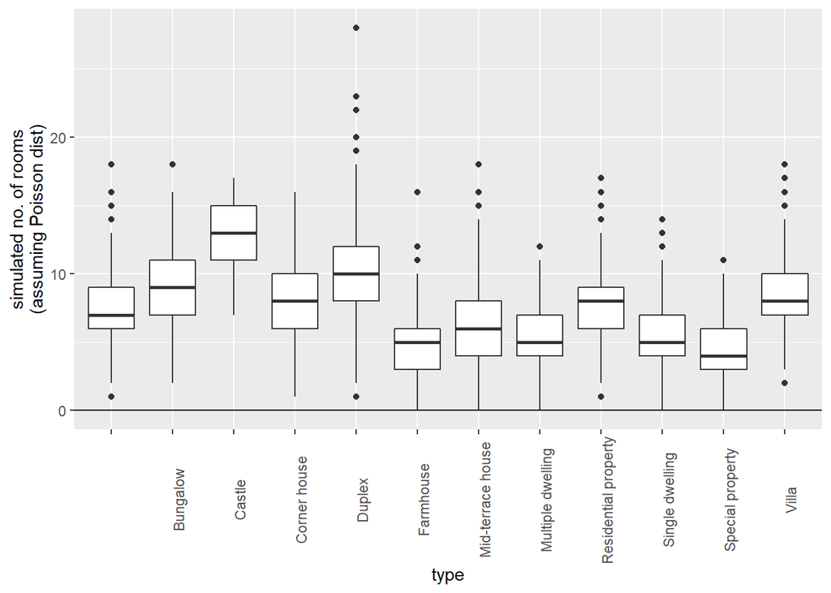

```r
ggplot(mapping = aes(y = sim.data.rooms.Poisson$sim_1,
x = data$Type)) +
geom_boxplot() +
geom_hline(yintercept = 0) +
ylab("simulated no. of rooms\n(assuming Poisson dist)") +
xlab("type") + theme(axis.text.x = element_text(angle = 90))
```

```r
#install.packages('mltools')
library(mltools)

# Resulting bins have an equal number of observations in each group
data[, "wt2"] <- bin_data(data$Price, bins=4, binType = "quantile")

# Resulting bins are equally spaced from min to max
data[, "wt3"] <- bin_data(data$Price, bins=4, binType = "explicit")

# Or if you'd rather define the bins yourself
data[, "wt4"] <- bin_data(data$Price, bins=c(-Inf, 250, 322, Inf), binType = "explicit")
head(data)
```

```
##     Price              Type Living_space Lot Rooms Bedrooms Bathrooms Floors
## 1  498000 Multiple dwelling       106.00 229     5        3         1      2
## 2  495000 Mid-terrace house       140.93 517     6        3         2     NA
## 3  749000         Farmhouse       162.89  82     5        3         2      4
## 4  259000         Farmhouse       140.00 814     4       NA         2      2
## 5  469000 Multiple dwelling       115.00 244     4        2         1     NA
## 6 1400000 Mid-terrace house       310.00 860     8       NA        NA      3
##   Year_built Furnishing_quality Year_renovated   Condition         Heating
## 1       2005             normal             NA refurbished central heating
## 2       1994              basic             NA refurbished   stove heating
## 3       2013                                NA dilapidated   stove heating
## 4       1900              basic           2000 fixer-upper central heating
## 5       1968            refined           2019 refurbished central heating
## 6       1969              basic             NA  maintained
##      Energy_source Energy_efficiency_class             State              City
```

[output cut: 20 more lines]

```r
glm.roomswt2 <- glm(Rooms ~ wt2,
family = "poisson",
data = data)

summary(glm.roomswt2)
```

```
##
## Call:
## glm(formula = Rooms ~ wt2, family = "poisson", data = data)
##
## Deviance Residuals:
##     Min       1Q   Median       3Q      Max
## -3.2229  -0.8439  -0.3171   0.4433   4.5174
##
## Coefficients:
##             Estimate Std. Error z value             Pr(>|z|)
## (Intercept) 1.922092   0.003783 508.099 < 0.0000000000000002 ***
## wt2.L       0.235488   0.007507  31.369 < 0.0000000000000002 ***
## wt2.Q       0.056346   0.007566   7.447   0.0000000000000952 ***
## wt2.C       0.041856   0.007624   5.490   0.0000000401941232 ***
## ---
## Signif. codes:  0 '***' 0.001 '**' 0.01 '*' 0.05 '.' 0.1 ' ' 1
##
## (Dispersion parameter for poisson family taken to be 1)
##
##     Null deviance: 13951  on 10317  degrees of freedom
## Residual deviance: 12833  on 10314  degrees of freedom
## AIC: 51023
##
## Number of Fisher Scoring iterations: 4
```

```r
set.seed(99)
sim.data.rooms.Poissonwt2 <- simulate(glm.roomswt2)
##
NROW(sim.data.rooms.Poissonwt2)
```

```
## [1] 10318
```

```r
head(sim.data.rooms.Poissonwt2)
```

```
##   sim_1
## 1     7
## 2     4
## 3    10
## 4    13
## 5     7
## 6    14
```

```r
tail(sim.data.rooms.Poissonwt2)
```

```
##       sim_1
## 10313    10
## 10314    16
## 10315    11
## 10316     5
## 10317     5
## 10318     9
```

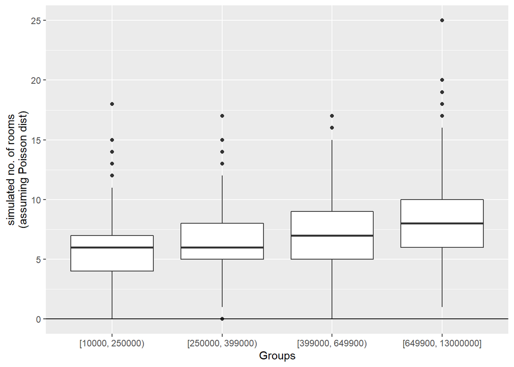

```r
library(ggplot2)
ggplot(mapping = aes(y = sim.data.rooms.Poissonwt2$sim_1,
x = data$wt2)) +
geom_boxplot() +
geom_hline(yintercept = 0) +
ylab("simulated no. of rooms\n(assuming Poisson dist)") +
xlab("Groups")
```

## 3.2 GLM - Binary Model

Let’s fit a binary model

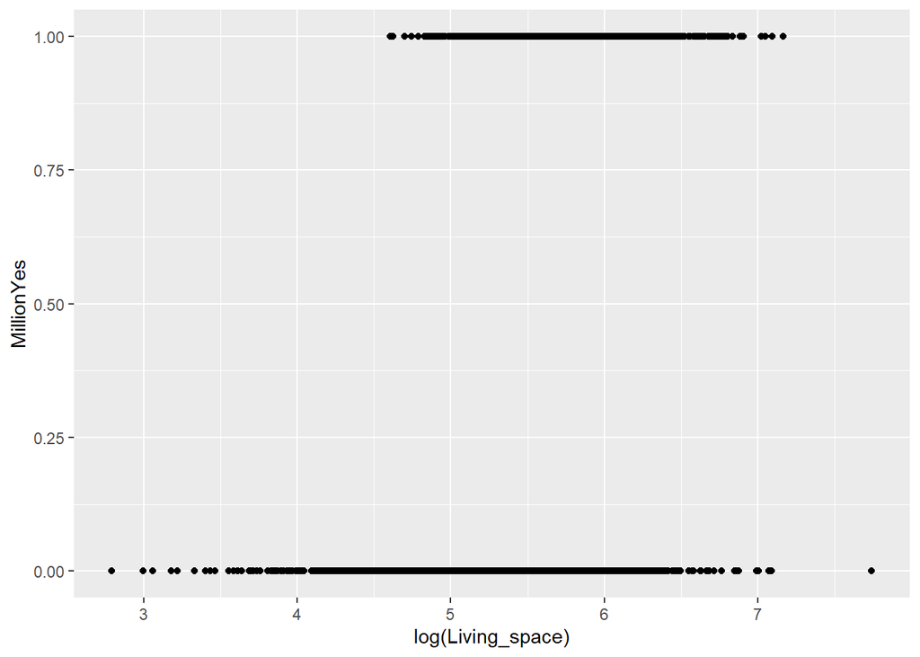

```r
data$MillionYes <- ifelse(data$Price > 1000000, 1, 0)
data$MillionYes

ggplot(data = data,
mapping = aes(y = MillionYes,
x = log(Living_space))) +
geom_point()
```

Let’s fit a logistic regression model and add fit to the this graph

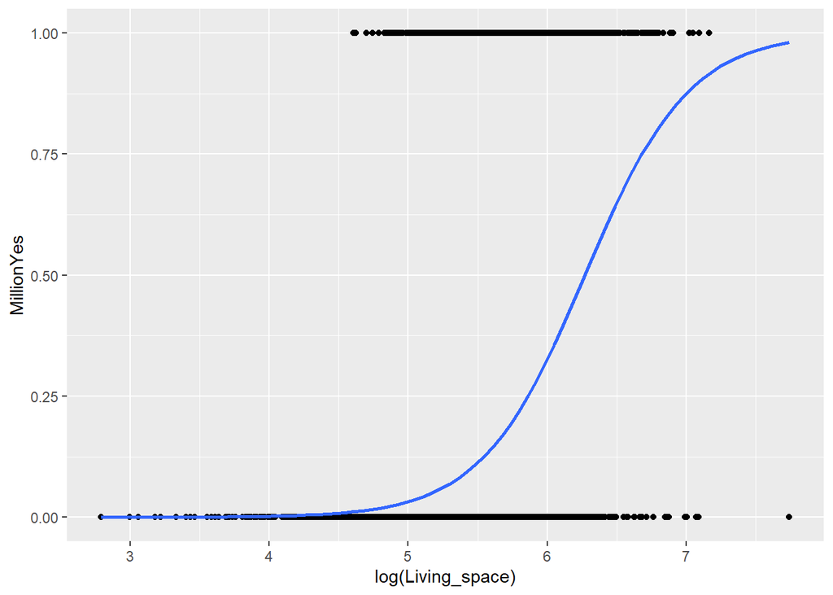

```r
ggplot(data = data,
       mapping = aes(y = MillionYes,
                     x = log(Living_space))) +
  geom_point() +
  geom_smooth(method = "glm",
              se = FALSE,
              method.args = list(family = "binomial"))
```